# Reproducible Research - June 2014

Ron Mashrouteh - Reproducible Research - Peer assignment 1

loading downloaded file **(activity.csv)**

```r
ds <- read.csv("~/activity.csv")
```

creating my dataset (myds) to get setps, dates and intervals without NA

```r
myds <- subset(ds, na.rm=TRUE, steps!=0, select=c(steps, date, interval))
```

globally declare **myds** so I don't have to keep typing myds$….

```r
attach(myds)
```

```r
mean(ds$steps, na.rm=TRUE)
```

```
## [1] 37.38
```

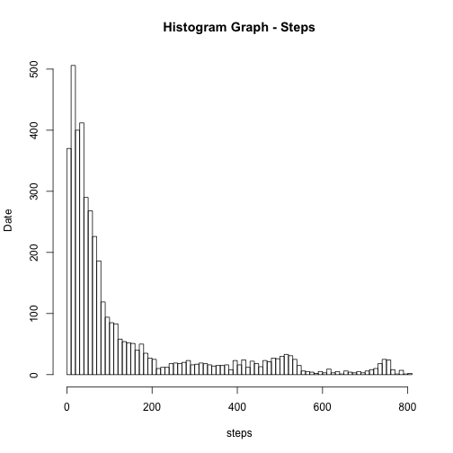

```r
hist(steps, breaks=100, main="Histogram Graph - Steps", ylab="Date", xlab="steps")
```

```r
perdaymean <- aggregate(list(steps=steps), na.rm=TRUE , list(dates = date), mean)
perdaymean
```

```
##         dates  steps
## 1  2012-10-02  63.00
## 2  2012-10-03 140.15
## 3  2012-10-04 121.16
## 4  2012-10-05 154.58
## 5  2012-10-06 145.47
## 6  2012-10-07 101.99
## 7  2012-10-09 134.85
## 8  2012-10-10  95.19
## 9  2012-10-11 137.39
## 10 2012-10-12 156.59
## 11 2012-10-13 119.48
## 12 2012-10-14 160.62
## 13 2012-10-15 131.68
## 14 2012-10-16 157.12
```

[output cut: 39 more lines]

```r
perdaymedian <- aggregate(list(steps=steps), na.rm=TRUE , list(date = date), median)
perdaymedian
```

```
##          date steps
## 1  2012-10-02  63.0
## 2  2012-10-03  61.0
## 3  2012-10-04  56.5
## 4  2012-10-05  66.0
## 5  2012-10-06  67.0
## 6  2012-10-07  52.5
## 7  2012-10-09  48.0
## 8  2012-10-10  56.5
## 9  2012-10-11  35.0
## 10 2012-10-12  46.0
## 11 2012-10-13  45.5
## 12 2012-10-14  60.5
## 13 2012-10-15  54.0
## 14 2012-10-16  64.0
```

[output cut: 39 more lines]

**Start preparing for plotting a graph of 5 minute interval**

```r
mi <- min(interval)
mi
```

```
## [1] 0
```

```r
mx <- max(interval)
mx
```

```
## [1] 2355
```

Generating aggreate of average steps per interval

```r
perdayavg <- aggregate(list(steps = steps), na.rm=TRUE , list(interval = interval), mean)
perdayavg
```

```
##     interval  steps
## 1          0  30.33
## 2          5  18.00
## 3         10   7.00
## 4         15   8.00
## 5         20   4.00
## 6         25  27.75
## 7         30  28.00
## 8         35  46.00
## 9         45  39.00
## 10        50   8.00
## 11        55   7.00
## 12       100  17.00
## 13       105  36.00
## 14       110   8.00
```

[output cut: 255 more lines]

Plotting the graph according to the aggregate we generated above

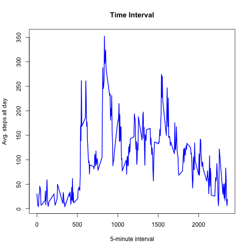

```r
plot(perdayavg, type = "l", xlim=c(mi, mx), lwd = 2, main="Time Interval", ylab="Avg. steps all day", xlab="5-minute interval", col="blue")
```

**which 5-minute interval contains the maximum number of steps**

MaxVal_avgsteps - get the maximum number of steps InterVal - get the Interval value for MaxVal_avgsteps.

```r
MaxVal_avgsteps <- max(perdayavg$steps)
InterVal <- subset(perdayavg$interval, perdayavg$steps == MaxVal_avgsteps)

MaxVal_avgsteps
```

```
## [1] 352.5
```

```r
InterVal
```

```
## [1] 835
```

# Inputing missing value

Loading the downloaded file as a new dataset

```r
Nwds <- read.csv("~/activity.csv")
```

Calculating total number of missing values (NAs)

```r
NAs <- length(Nwds$step[Nwds$step =="NA"])
NAs
```

```
## [1] 2304
```

Subset & Fill the missing value with 0s (replacing NA with 0)

```r
Nwds <- subset(Nwds, select=c(steps, date, interval))
Nwds
```

[output not shown]

[output cut: 17554 more lines]

Setting to 0s

```r
Nwds[is.na(Nwds)] <- 0
Nwds
```

[output not shown]

[output cut: 17554 more lines]

Remove all the rows that contain NA values

We load a fresh copy of the csv file to get all data with NA since we substitute them with 0s in the previous step

```r
Newds <- read.csv("~/activity.csv")
Newds
```

[output not shown]

[output cut: 17554 more lines]

Remove all rows that contan NA

```r
remv <-na.omit(Newds)
remv
```

[output not shown]

[output cut: 15250 more lines]

Calculate the mean and median values after removing all rows that contained NA

```r
perdayavg_mean_noNA <- aggregate(list(steps = remv$steps), list(interval = remv$interval), mean)
perdayavg_median_noNA <- aggregate(list(steps = remv$steps), list(interval = remv$interval), median)
```

Generate histogram graphs for mean and median

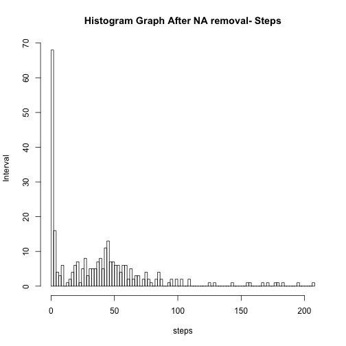

```r
hist(perdayavg_mean_noNA$steps, breaks=100, main="Histogram Graph After NA removal- Steps", ylab="Interval", xlab="steps")
```

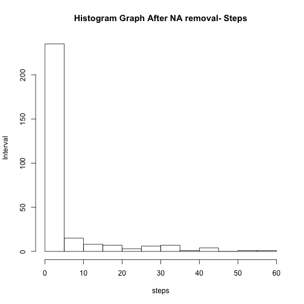

```r
hist(perdayavg_median_noNA$steps, breaks=10, main="Histogram Graph After NA removal- Steps", ylab="Interval", xlab="steps")
```

Loadin the csv file one more time for the last part of the assignment

```r
lastpart <- read.csv("~/activity.csv")

NAs <- length(lastpart$step[lastpart$step =="NA"])
shwval <- NAs

lastpart[is.na(lastpart)] <- 0
```

Specifying the if the date is a weekday or weekend

```r
lastpart$weekday = weekdays(as.Date(lastpart$date, format = "%Y-%m-%d"))
lastpart$weekday.type = factor(ifelse(lastpart$weekday == "Sunday" | lastpart$weekday ==
                                             "Saturday", "weekend", "weekday"), levels = c("weekday", "weekend"))


lastpart.weekdays = lastpart[lastpart$weekday.type == "weekday", ]
lastpart.weekend = lastpart[lastpart$weekday.type == "weekend", ]
avg.steps.per.interval.weekdays = sapply(split(lastpart.weekdays$steps, lastpart.weekdays$interval), mean)
avg.steps.per.interval.weekend = sapply(split(lastpart.weekend$steps, lastpart.weekend$interval), mean)
```

Creating the panel plot for the 5-minute interval.

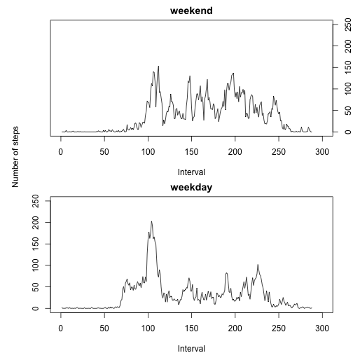

```r
DoPlot = function() {
    par(mfrow = c(2, 1), mar = c(4, 5, 2, 2))
    plot(avg.steps.per.interval.weekend, type = "l", yaxt = "n", ylim = c(0, 250), xlim = c(0, 300), main = "weekend", ylab = "", xlab = "Interval")
    axis(side = 4, at = seq(0, 250, 50), labels = seq(0, 250, 50))
    plot(avg.steps.per.interval.weekdays, type = "l", ylim = c(0, 250), xlim = c(0, 300), main = "weekday", ylab = "", xlab = "Interval")
    par(mfrow = c(1, 1), mar = c(3, 2, 2, 2))
    mtext(text = "Number of steps", side = 2)
    par(mar = c(5, 5, 5, 2))
}

DoPlot()
```